# Spain’s Latinobarometer: Before and After the Crisis

David Tomczyk

# Part A - Surveys to Compare

Questionnaires to compare: Question about most important issues facing Spain from the Latinobarometer Spain 2006 vs 2009

# Background

Spain’s economy grew rapidly during the end of the 90’s and the beginning of the 2000’s. From 1996 to 2007, real estate prices rose 200%. However, this real estate bubble inevitably broke, and in February 2009 it was confirmed that Spain, along with other European economies, had officialy entered recession.The economy contracted 3.7% in 2009, and unemployment rose rapidly.

# B - Description of Graphs

Graphs to be made:  
I envision creating one of two graphs, both of which are dotplots. In both plots the response levels will be on the Y-axis. Given there are 15+ response levels, I will likely only choose 4 or 5. On the X axis will be the proportion of respondents choosing a given option.

The first dotplot has all years on a single graph. The two different years are designated by different colors or shapes. This way, one can easily see the difference in proportion of people choosing a response between both years. The second dot plot has two facets: one for 2006 and another for 2009, arranged vertically. This arrangement will allow people to see how responses varied between the two years, and also allow for easy comparison for how they changed.

# C - Shape of Data

In order to fulfill my graph’s data contract, a row of my data frame will have to have the shape:

{Year: “”, Response: “”, Value: “”}

# D-F: Script, Graph, and Fantasy Functions

# Create Data Frame for Spain’s LatinoBarometer 2006

Quick notes:

2476 observations in 2006 Spain Latinobarometer  
Question of interest is P10ST

```r
 #read csv file
lb2006_raw <-read.csv("lb2006.csv")

#check structure
str(lb2006_raw)
```

```
## 'data.frame':    22708 obs. of  299 variables:
##  $ NUMINVES: int  2006 2006 2006 2006 2006 2006 2006 2006 2006 2006 ...
##  $ IDENPA  : int  32 32 32 32 32 32 32 32 32 32 ...
##  $ NUMENTRE: int  1 2 3 4 5 6 7 8 9 10 ...
##  $ REG     : int  32001 32001 32001 32001 32001 32001 32001 32001 32001 32001 ...
##  $ CIUDAD  : int  32001001 32001001 32001001 32001001 32001001 32001001 32001001 32001001 32001001 32001001 ...
##  $ TAMCIUD : int  8 8 8 8 8 8 8 8 8 8 ...
##  $ COMDIST : int  4 8 11 10 11 10 7 5 6 10 ...
##  $ SEXO    : int  1 2 1 2 2 1 1 1 1 2 ...
##  $ CODIGO  : int  4 13 9 17 9 9 17 20 11 9 ...
##  $ DIAREAL : int  13 30 2 3 2 3 25 28 25 3 ...
##  $ MESREAL : int  10 10 11 11 11 11 10 10 10 11 ...
##  $ INI     : int  1800 1140 1500 1400 1900 1000 1705 1400 1420 910 ...
##  $ FIN     : int  1850 1230 1540 1500 1950 1045 1800 1440 1510 1000 ...
##  $ DURA    : int  50 50 40 60 50 45 55 40 50 50 ...
```

[output cut: 86 more lines]

```r
#Subset to only include data for Spain
spain2006 <- subset(lb2006_raw, IDENPA == 724)

#Select only the variables I'm interested in (Survey Year, Question Responses)
spain2006_rel <- subset(spain2006, select=c(NUMINVES,P10ST))

#Check for NA's
sum(is.na(spain2006_rel))
```

```
## [1] 0
```

```r
#FREQ table of data response*sex (includes only column % to check with codebook)
#CrossTable(spain2006_rel$P10ST,spain2006_rel$NUMINVES, prop.r = FALSE, prop.chisq=FALSE)

#Add a variable that will be summed in aggregate to gives counts for each level
spain2006_rel$Count <- 1

#Aggregate the count variable by Year, response, and gender
spain2006_levels_raw <-aggregate(spain2006_rel, by=list(spain2006_rel$NUMINVES, spain2006_rel$P10ST), FUN=sum)

#Rename the new variables
colnames(spain2006_levels_raw)[1] <- "Year"
colnames(spain2006_levels_raw)[2] <- "Response"

#Check to make sure that the responses stay the same
sort(unique(spain2006_levels_raw$Response)) == sort(unique(spain2006_rel$P10ST)) #checking to make sure that the responses stay the same
```

```
##  [1] TRUE TRUE TRUE TRUE TRUE TRUE TRUE TRUE TRUE TRUE TRUE TRUE TRUE TRUE
## [15] TRUE TRUE TRUE TRUE TRUE TRUE TRUE TRUE
```

```r
#Subset data frame to only include the correct, renamed variables
spain2006_final <- subset(spain2006_levels_raw, select=c(Year, Response, Count))

#check to make sure total number of responses still matches

sum(spain2006_final$Count)
```

```
## [1] 2476
```

```r
#Add new variable of proportion of people giving each response
spain2006_final$Proportion <- round((spain2006_final$Count/2476)*100, digits = 1)
```

# Create Data Frame for Spain’s LatinoBarometer 2009

Quick notes:

2486 observations in 2009 Spain Latinobarometer  
Question of interest is P2ST

```r
#Read csv file
lb2009_raw <-read.csv("lb2009.csv", stringsAsFactors=FALSE) #read file

#Check structure
str(lb2009_raw)
```

```
## 'data.frame':    22690 obs. of  368 variables:
##  $ NUMINVES: int  2009 2009 2009 2009 2009 2009 2009 2009 2009 2009 ...
##  $ IDENPA  : int  32 32 32 32 32 32 32 32 32 32 ...
##  $ NUMENTRE: int  1 2 3 4 5 6 7 8 9 10 ...
##  $ REG     : int  32301 32301 32301 32301 32301 32301 32301 32301 32301 32301 ...
##  $ CIUDAD  : int  32301000 32301000 32301000 32301000 32301000 32301000 32301000 32301000 32301000 32301000 ...
##  $ TAMCIUD : int  7 7 7 7 7 7 7 7 7 7 ...
##  $ COMDIST : int  1 1 1 1 1 1 1 1 2 2 ...
##  $ CODIGO  : int  16 16 16 16 16 16 16 16 16 16 ...
##  $ DIAREAL : int  13 13 13 13 13 13 13 13 5 5 ...
##  $ MESREAL : int  10 10 10 10 10 10 10 10 10 10 ...
##  $ INI     : int  1105 1150 1245 1340 1445 1540 1630 1725 1030 1120 ...
##  $ FIN     : int  1140 1225 1320 1415 1520 1615 1705 1805 1110 1155 ...
##  $ DURA    : int  35 35 35 35 35 35 35 40 40 35 ...
##  $ TOTREVI : int  0 0 0 1 2 2 4 2 0 0 ...
```

[output cut: 86 more lines]

```r
#Subset to only include data for Spain
spain2009 <- subset(lb2009_raw, IDENPA == 724)

#Select only the variables I'm interested in (Survey Year, Question Responses)
spain2009_rel <- subset(spain2009, select=c(NUMINVES,P2ST))

#Check for NA's
sum(is.na(spain2009_rel))
```

```
## [1] 0
```

```r
#FREQ table of data response*sex (includes only column % to check with codebook)
#CrossTable(spain2009_rel$P2ST,spain2009_rel$NUMINVES, prop.r = FALSE, prop.chisq=FALSE)

#Add a variable that will be summed in aggregate to gives counts for each level
spain2009_rel$Count <- 1

#Aggregate the count variable by Year, response, and gender
spain2009_levels_raw <-aggregate(spain2009_rel, by=list(spain2009_rel$NUMINVES, spain2009_rel$P2ST), FUN=sum)

#Rename the new variables
colnames(spain2009_levels_raw)[1] <- "Year"
colnames(spain2009_levels_raw)[2] <- "Response"

#Check to make sure that the responses stay the same
sort(unique(spain2009_levels_raw$Response)) == sort(unique(spain2009_rel$P2ST))
```

```
##  [1] TRUE TRUE TRUE TRUE TRUE TRUE TRUE TRUE TRUE TRUE TRUE TRUE TRUE TRUE
## [15] TRUE TRUE TRUE TRUE TRUE TRUE
```

```r
#Subset data frame to only include the correct, renamed variables
spain2009_final <- subset(spain2009_levels_raw, select=c(Year, Response, Count))

#check to make sure total number of responses still matches
sum(spain2009_final$Count)
```

```
## [1] 2486
```

```r
#Add new variable of proportion of people giving each response
spain2009_final$Proportion <- round((spain2009_final$Count/2476)*100, digits = 1)
```

# Create Final Data Frame

```r
#Concatenate 2006 and 2009 Data Frames
spain <- rbind(spain2006_final, spain2009_final)

#There are 22 response levels to the question of interest. Subsetting it down to only include a few different responses:
  #Terrorism - 3 (2006 & 2009)
  #Unemployment - 7 (2006 & 2009)
  #Gas/Fuel - 22 (2006 & 2009)
  #Economy - 25 (2006 & 2009)
  #Social Problems - 31 (2006 & 2009)

#Select the above variables:
spain_final <- subset(spain, Response %in% c(3,7,22,25,31))

#Rename response levels:

spain_final$Response[spain_final$Response == 3] <- "Terrorism"
spain_final$Response[spain_final$Response == 7] <- "Unemployment"
spain_final$Response[spain_final$Response == 22] <- "Gas/Fuel"
spain_final$Response[spain_final$Response == 25] <- "Economy"
spain_final$Response[spain_final$Response == 31] <- "Social Problems"
```

# Plotting the data (Preliminary)

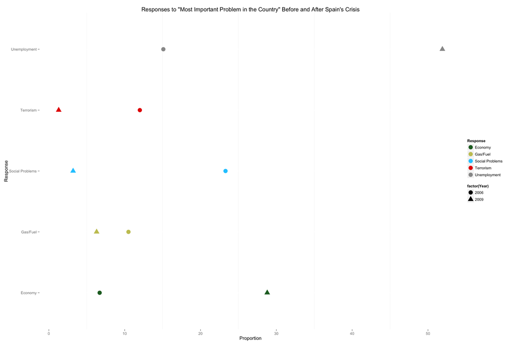

```r
title <- ggtitle("Responses to \"Most Important Problem in the Country\" Before and After Spain's Crisis")

bg <- theme(panel.background = element_blank())

colors.custom <- scale_colour_manual(values=c("#216C2A", "#C7C561","#1dcaff", "#E60000","#999999"))

#Dot Plot - One plot, stacked

ggplot(spain_final, aes(x = Proportion, y = Response, color = Response)) +
  geom_point(aes(shape = factor(Year)), size = 5, position ="identity") + colors.custom + title + bg
```

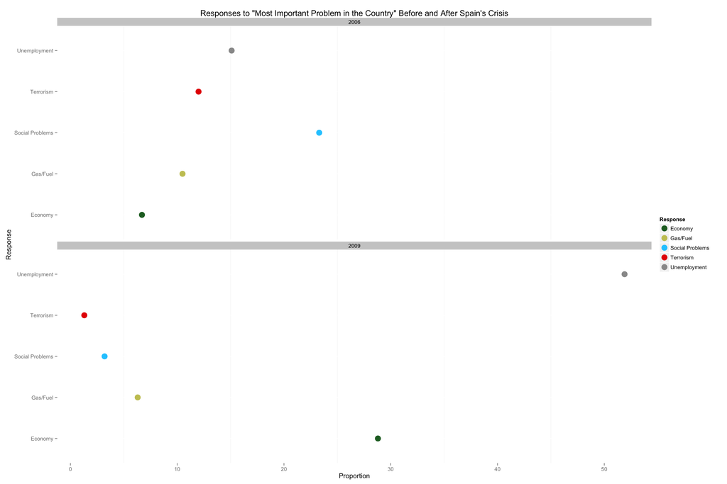

```r
#Dot Plot - Two Facets

ggplot(spain_final, aes(x = Proportion, y = Response, colour = Response)) +
  geom_point(size = 5) + facet_wrap(~ Year, ncol = 1) + colors.custom + title + bg
```

# Fantasy Function calls

Take blocks of code that created each data frame, and abstract them into functions

Didn’t have time to actually make the functions, will return to them later.

```r
loadsurvey <- function("csvname"){
  #loads survey and checks structure
  survey1 <- read.csv("csvname")
  str(lb2006_raw)
  return(survey1)
}

select_relevant <- function(dataframe= , variables = (list), variable_to_be_valued=, value=##){
  #selects relevant variables and values (ie country code)
  survey1 <- subset(dataframe, variable_to_be_valued == value)
  survey2 <- subset(survey2, select=c(list))
  return(survey2)
}

complete_agg <- function(dataframe=, agg_variables=, FUN=, listofnewvarnames=(list)
  survey 1 <-aggregate(dataframe, by=list(agg_variables), FUN=FUN)
  #Figure out a way to have the newly created variables renamed into something useful, maybe using list like above, maybe not
  colnames(survey1)[1] <- listofnewvarnames[1]
  colnames(survey1)[2] <- listofnewvarnames[2]
  #Check to make sure that the responses stay the same
  return(survey2)
}
```

# Creating Functions

```r
#To be continued...
```